# Linear Weights by Era

An Experiemnt in Using Change Point Detection to Delineate Offensive Environments

## Baseball Doesn’t Change (Often)

What is the “average” that we compare players against? For things like WAR, or the various “plus” stats (OPS+, wRC+, etc.), we compare players the the league average that season. wOBA is scaled to that season’s league OBP. There’s nothing wrong with this approach. For something like WAR, where you want to know how many runs above average that player actually produced in that season, it’s probably the right approach. When it comes to evaluating how good or bad a player is relative to his peers, this feels a bit like confusing weather and climate - year-to-year changes in league OBP, say, are more likely fluctuations around the league’s underlying “true talent” level.

Of course, given a long enough run, sometimes baseball *does* change. Expansion changes the underlying talent level of the league, bringing in more players who would not have made it before. Changing the height of the mound, or introducing a new ball change the dynamics of run scoring - is the league closer to Whitey Ball or the Bomba Squad? These changes, if they have a large enough impact, might delineate environments in which players played. The years in between can probably be thought of as constant. 2019 Juan Soto wouldn’t be a different quality player if you dropped him into 2021, because 2019 and 2021 are basically the same (ok, with the ball changes and sticky stuff enforcement in recent seasons, this might not be quite right).

So can we find where the changes occur, and fit multi-year linear weights for the years in between?

## Part 1: Change Points

### BOCPD

The main goal of this exercise is to apply a change point detection (CPD) algorithm to a real-world problem. I’m using the Bayesian Online Change Point Detection (BOCPD) algorithm introduced by [Adams and McKay](https://arxiv.org/abs/0710.3742). I’m using this method because 1) Bayesian stuff is cool and 2) because it performed really well in a recent [benchmarking of CPD algorithms](https://arxiv.org/pdf/2003.06222.pdf). The actual analysis was run using the [`ocp`](https://CRAN.R-project.org/package=ocp) package in `R`.

Bayesian Online Change Point Detection iteratively fits a probability distribution over the possible run lengths, $r_t=0, 1, 2,..., T$, (time steps since the last change point) given each new data point observed. As described by Adams & McKay, we assume we have a series of sequential observations, $\textbf{x}$, of length $T$, where the distribution of $x_t$ depends only on the data since the last change point $\textbf{x}_{t}^{(r)}$. It fits a posterior distribution
$$P(r_t|\textbf{x}_{1:t})=\frac{P(r_t, \textbf{x}_{1:t})}{P(\textbf{x}_{1:t})}$$
where the joint distribution $P(r_t, \textbf{x}_{1:t})$ factors into
$$P(r_t, \textbf{x}_{1:t}) = \sum_{r_t-1}P(r_t|r_{t-1})P(x_t|r_{t-1},\textbf{x}_t^{(r)})P(r_{t-1},\textbf{x}_{1:t-1})$$
$P(r_t|r_{t-1})$ is the change point prior and we can make things easy be assuming a distribution with a constant hazard rate $\lambda$ (a geometric distribution) so that the prior is only
$$P(r_t|r_{t-1}) = \begin{cases} 1/\lambda & if~~~r_t = 0 \\ 1-1/\lambda & if~~~r_t=r_{t-1}+1\end{cases}$$
$P(x_t|r_{t-1},\textbf{x}_t^{(r)})$ is the distribution of $x_t$ conditioned only on the observations since the last hypothesized change point ($r_{t-1}=0, 1, ..., t-1$), and $P(r_{t-1},\textbf{x}_{1:t-1})$ is the “message” passed along from the last iteration. This message is the joint distribution of $P(r_t, \textbf{x}_{1:t})$, calculated in the previous iteration. The iterative algorithm can be efficiently implemented if we assume an exponential family distribution (for instance, a normal distribution) for $x$. This is because the parameters for the predictive distribution $P(x_t|r_{t-1},\textbf{x}_t^{(r)})$ can be updated using only the previously inferred parameters and the new observation.

This is a pretty gloss-over explanation, and may be missing something. For a more thorough look at BOCPD see the [Adams and McKay](https://arxiv.org/abs/0710.3742) paper or these [two](http://gregorygundersen.com/blog/2019/08/13/bocd/) [posts](http://gregorygundersen.com/blog/2020/10/20/implementing-bocd/) by Greg Gundersen, the latter of which walks through an implementation of the algorithm in Python for the univariate case.

### Data

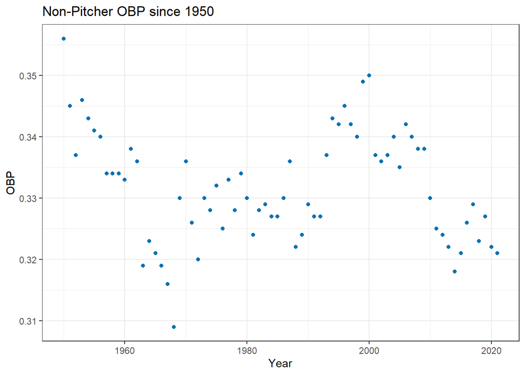

Figure 1: League on-base percentage (non-pitcher), 1950-2021

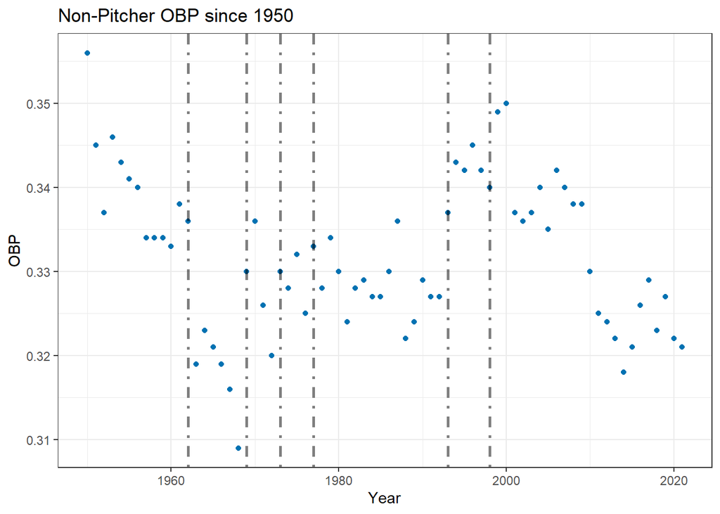

Figure 2: League OBP with possible change points marked.

Some look like matches, some don’t. There doesn’t seem to be any change in ’73 or ’77, or 1998, and it looks like something changes around 2010. What that could be, I’m not sure. OBP isn’t the only aspect to offense, though.

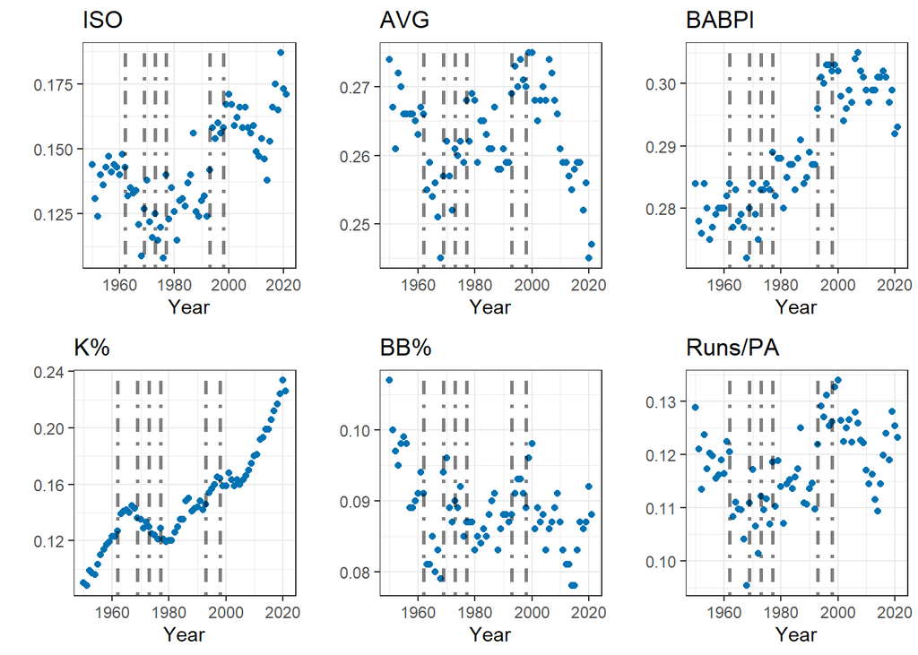

Figure 3: Other aspects of batting, 1950-2021

Figure 3 shows isolated slugging, batting average, BABIP, strikeout percentage, walk percentage and runs per plate appearance each year since 1950 with the same candidate change points marked. Some metrics, like average and runs per plate appearance, look like they track OBP more or less. ISO and BABIP look like they might just have a single change point around 1993, while walk and strikeout percentage are harder to get a handle on. K% changes don’t lineup very well with the proposed change points, but there are clearly a couple changes in trend. BB% looks more consistent with random change around a constant mean (note that the range is only around 3%, whereas the range for K% is more like 15%).

So which variables should we choose to estimate change points? I think an offensive environment can be broken down into 1) how many runs are being scored and 2) how those runs are being scored. Clearly, the crux of an offensive environment is, well, how much offense there is. That doesn’t mean the dynamics of run scoring are the same in similar run scoring environments, however. Take a look at a few comparably high-scoring seasons:

| year | RperPA | AVG | OBP | ISO | K. | BB. |
| --- | --- | --- | --- | --- | --- | --- |
| 1953 | 0.124 | 0.272 | 0.346 | 0.140 | 0.097 | 0.095 |
| 1987 | 0.125 | 0.267 | 0.336 | 0.156 | 0.150 | 0.091 |
| 2017 | 0.124 | 0.259 | 0.329 | 0.175 | 0.212 | 0.087 |

Going off the proposed change points these three season would come from different offensive era. They all have just about the same runs per plate appearance (they rank 18th, 16th, and 17th since 1950, respectively) but you can clearly see the increasing importance of power over getting on base and putting the ball in play as a driver of run scoring. 2014 and 1966 would also be in different eras, and rank 64th and 63rd in runs per plate appearance. Before getting too excited about the proposed change points it’s worth noting that, with the exception of K%, they have nearly identical stats:

| year | RperPA | AVG | OBP | ISO | K. | BB. |
| --- | --- | --- | --- | --- | --- | --- |
| 1966 | 0.110 | 0.256 | 0.319 | 0.134 | 0.140 | 0.080 |
| 2014 | 0.109 | 0.255 | 0.318 | 0.138 | 0.199 | 0.078 |

2014 is a bit of a weird season for its time in terms of power - you have to go back to 1993 to find another season where the league’s ISO was under 0.145.

So we want runs per plate appearance - a measure of overall run scoring. ISO and OBP also seem like good choices to capture run scoring dynamics - power vs moving the line. Strikeout percentage seems related to how often the ball is put in play, which relates to run scoring dynamics so I’ll include K% as well. There are other choices that could be included (home run percentage? stolen bases per base runner?) that are related how runs are scored, but for now I think these choices should capture the general dynamics.

### Results

First, to see what can be learned from just the level of run scoring, I ran a model with just runs per plate appearance.

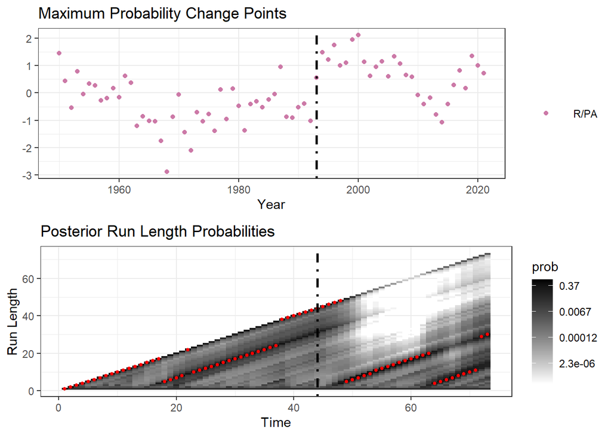

```
## Maximum Probability Change Points:  1993
```

What’s shown here is this:

- On top is the normalized runs per plate appearance data, with the dashed line marking the year 1993. This point has $r_t=0$ as the highest probability.
- Underneath is a plot of the posterior probability of $r_t=t$ at each time step, shaded by their log probability. Plotted in red are the maximum probabilities of $r_t$ at time $t$.

The `ocp` algorithm (at least with how I parameterized it) only found one change point, 1993. Notice that there is a lot of uncertainty around that outcome, though. The area of higher density and the points of maximum probability below the diagonal in the 1960s - 1980s give weight to a possible change point some time in the mid-to-late 1960s. Likewise, for the region near the x-axis starting sometime around 2010.

(Note: The red maximum probability dot for the year 1993 is actually on the diagonal, as are the few dots afterwards. What I think is going on here is that given the probability density of $r_t$ later in the sequence, which clearly indicates a change point occurred, the function is inferring that the change point had to happen in 1993? I’m not entirely sure about that, though.)

Ok, so just using runs per plate appearance we’ve identified one change point, with evidence for a couple others. What happens when all four variables are included?

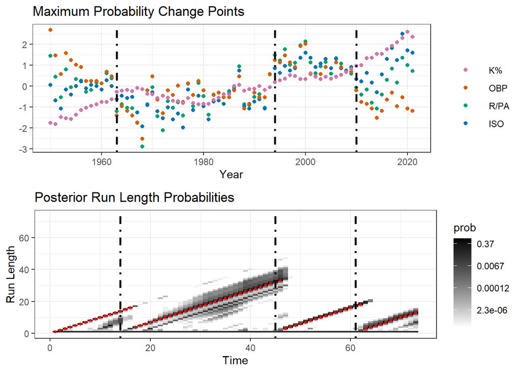

```
## Maximum Probability Change Points:  1963 1994 2010
```

The figure above plots the same thing as before, except the top plot has all four input variables, scaled to have zero mean and standard deviation 1. The posterior probabilities for $r_t$ are much tighter this time, and three change points have been found: 1963, 1994, 2010. 1963 was the year after two straight expansions in 1961 and 1962, which fits with expectations. Likewise, the league expanded in 1993, which lends credence to a change point starting in 1994. The offensive environment seems to change in different directions following each - run scoring dropped after 1962, and rose after 1993. Why that would be, I’m not sure. There’s still some ambiguity about possible change points before and after 1963, but not a ton.

The model is pretty sure a change point occured in 2010. Looking at the top plot of R/PA, ISO, OBP and K%, something is clearly going on. For most of the years in the series, ISO, OBP and R/PA are at kind of similar levels, relative to their overall mean, with K% dipping modestly in the 1970’s but otherwise rising throughout. Starting in 2010 these values start to really diverge. They all drop for a few years, with OBP falling off significantly, before ISO soars, dragging R/PA up with it, while OBP kind of just stays low. If I were to plot batting average along with the others you would see an even bigger drop than OBP. The spike in ISO is likely due to the changes MLB made to the ball starting in 2015. But what’s going on with OBP and AVG? Did the shift really have that strong an effect? The “fly ball revolution”? It’s hard to imagine a change in approach having that big of an effect. Did pitchers magically get better? Some combination thereof?

What the model doesn’t pick up on is expansion and the lowering of the mound in 1969 or the introduction of the DH in 1973. Neither does it pick up on expansion in 1977 or 1998. It’s possible that some expansions didn’t change the league’s talent level while some did, but this does make me wonder if the model is just picking up noise. Though as mentioned above there is some noticeable mass around the maximum probability line running through the 1960s-80s, indicating some evidence for change points both before and after 1963. There’s also a region of higher mass associated with a possible change point around 2015 when MLB started messing around with the ball. Perhaps with more years, or different variables, the model would identify those as change points.

## Part 2: Linear Weights

Now that we have our change points delineating different eras of MLB offense we can calculate linear weights used in wOBA for use in that era, rather than on a yearly basis. The process for calculating linear weights is pretty standard sabermetrics by now and you can get an overview at [fangraphs](https://library.fangraphs.com/principles/linear-weights/). The very very short version is:

- Find, on average, how many runs are scored through the end of an inning starting with each of the [24 base-out states](https://library.fangraphs.com/misc/re24/)
- Calculate the average change in run expectancy for each component event of wOBA

I did this using Retrosheet play-by-play data for the the calculations. I got the already-parsed Retrosheet for the years 1950-2019 from Jerry Word’s [github](https://github.com/jerryword/retrosheet). This is an awesome resource (he has other Retrosheet data parsed and available, too) that made getting all the data together much quicker. For 2020 and 2021 I went through the process of parsing the event files myself with the Chadwick tools (again, awesome resource).

The linear weights for the different eras are:

| Era | lg_obp | wHBP | wBB | w1B | w2B | w3B | wHR | SB | CS |
| --- | --- | --- | --- | --- | --- | --- | --- | --- | --- |
| 1950-62 | 0.340 | 0.585 | 0.566 | 0.722 | 1.016 | 1.311 | 1.682 | 0.2 | -0.402 |
| 1963-93 | 0.327 | 0.553 | 0.530 | 0.691 | 0.986 | 1.267 | 1.657 | 0.2 | -0.407 |
| 1994-2009 | 0.341 | 0.616 | 0.591 | 0.745 | 1.050 | 1.342 | 1.686 | 0.2 | -0.446 |
| 2010-21 | 0.324 | 0.579 | 0.558 | 0.702 | 1.003 | 1.305 | 1.650 | 0.2 | -0.415 |

The weights do change by era, but there aren’t any huge differences. We probably shouldn’t expect there to be - baseball changes, but it doesn’t change *that* much, and using these weights wouldn’t change any player’s wOBA in any given year very much. Still, the outcome of the change point analysis suggests that there are eras of MLB offense, and that within those eras the run environment doesn’t really change. Dropping 2019 Juan Soto in 2021 wouldn’t change how we think about 2019 Juan Soto, but dropping 2019 Juan Soto in 2002 might. At least a little bit.

## P.S.

Just to see if changing the variables would change the results, I ran the `ocp` model with a few different combination of offensive stats. Triple slash line? Same change points. K%, BB%, R/PA and BABIP? Same change points. A couple other combinations of those inputs? Same. Varying the value of $\lambda$ up to $200$ also resulted in the same change points. I’m tempted to say that this is evidence that something really did change in the dynamics of the game around these points. The fact that the two expansion years the model identified changed scoring in opposite directions, and that the other expansion years apparently did not have a large enough effect to be identified, still make me somewhat skeptical.